# Cyclistic Bike-Share Analysis

Daniel Eniola

2026-03-01

## 1. Introduction

### Background

This case study is the Google Data Analytics Certificate capstone project. I am acting as a junior data analyst at **Cyclistic**, a fictional bike-share company based in Chicago.

Cyclistic offers a fleet of bikes that can be unlocked from one station and returned to any other station in the network. Riders can purchase:

- **Single-ride passes** (casual riders)
- **Full-day passes** (casual riders)
- **Annual memberships** (members)

The marketing director believes that converting casual riders into annual members is key to Cyclistic’s future growth. Three questions will guide the future marketing program:

- **How do annual members and casual riders use Cyclistic bikes differently?**
- **Why would casual riders buy Cyclistic annual memberships?**
- **How can Cyclistic use digital media to influence casual riders to become members?**

I have been assigned the **first question** as my focus:

> **How do annual members and casual riders use Cyclistic bikes differently?**

The insights from this analysis will inform a marketing strategy to convert casual riders into annual members.

## 2. Prepare

### Load Libraries

```r
library(tidyverse)
library(janitor)
library(scales)
```

### Load Data

Each monthly CSV file was loaded separately and combined into one dataframe.

```r
m01 <- read_csv("../Cyclistic_Analysis/csv_data/202501-divvy-tripdata.csv")
m02 <- read_csv("../Cyclistic_Analysis/csv_data/202502-divvy-tripdata.csv")
m03 <- read_csv("../Cyclistic_Analysis/csv_data/202503-divvy-tripdata.csv")
m04 <- read_csv("../Cyclistic_Analysis/csv_data/202504-divvy-tripdata.csv")
m05 <- read_csv("../Cyclistic_Analysis/csv_data/202505-divvy-tripdata.csv")
m06 <- read_csv("../Cyclistic_Analysis/csv_data/202506-divvy-tripdata.csv")
m07 <- read_csv("../Cyclistic_Analysis/csv_data/202507-divvy-tripdata.csv")
m08 <- read_csv("../Cyclistic_Analysis/csv_data/202508-divvy-tripdata.csv")
m09 <- read_csv("../Cyclistic_Analysis/csv_data/202509-divvy-tripdata.csv")
m10 <- read_csv("../Cyclistic_Analysis/csv_data/202510-divvy-tripdata.csv")
m11 <- read_csv("../Cyclistic_Analysis/csv_data/202511-divvy-tripdata.csv")
m12 <- read_csv("../Cyclistic_Analysis/csv_data/202512-divvy-tripdata.csv")

# Combine into one dataframe
all_trips <- bind_rows(m01, m02, m03, m04, m05, m06, m07, m08, m09, m10, m11, m12)
```

### Explore the Data

```r
glimpse(all_trips)
```

```
## Rows: 5,552,092
## Columns: 13
## $ ride_id            <chr> "FD0EB1D32AF0D47E", "FB27405C3F8C824F", "6FAFA17094…
## $ rideable_type      <chr> "classic_bike", "classic_bike", "electric_bike", "e…
## $ started_at         <dttm> 2026-01-31 09:13:09, 2026-01-15 14:25:42, 2026-01-…
## $ ended_at           <dttm> 2026-01-31 09:28:10, 2026-01-15 14:33:18, 2026-01-…
## $ start_station_name <chr> "Central St & Girard Ave", "Shore Dr & 55th St", "H…
## $ start_station_id   <chr> "CHI02042", "CHI00394", "CHI02087", "CHI00286", "CH…
## $ end_station_name   <chr> "Dodge Ave & Church St", "Woodlawn Ave & 55th St", …
## $ end_station_id     <chr> "CHI00741", "CHI00423", NA, NA, NA, NA, NA, NA, NA,…
## $ start_lat          <dbl> 42.06431, 41.79521, 41.93247, 41.89453, 41.88166, 4…
## $ start_lng          <dbl> -87.68615, -87.58071, -87.64242, -87.65341, -87.641…
## $ end_lat            <dbl> 42.04831, 41.79526, 41.94000, 41.83000, 41.89000, 4…
## $ end_lng            <dbl> -87.69822, -87.59647, -87.64000, -87.67000, -87.630…
## $ member_casual      <chr> "member", "casual", "member", "member", "member", "…
```

The combined dataset contains **5,552,092** rows and **13** columns.

### Check for Missing Values

```r
colSums(is.na(all_trips))
```

```
##            ride_id      rideable_type         started_at           ended_at
##                  0                  0                  0                  0
## start_station_name   start_station_id   end_station_name     end_station_id
##            1186374            1186374            1246827            1246827
##          start_lat          start_lng            end_lat            end_lng
##                  0                  0               5670               5670
##      member_casual
##                  0
```

**Key observations on missing data:**

- `start_station_name` and `start_station_id`: 1,186,374 missing — mostly electric bikes that do not require docking at a named station. These were **retained** as they represent valid rides.
- `end_station_name` and `end_station_id`: 1,246,827 missing — same reason as above. **Retained.**
- `end_lat` and `end_lng`: 5,670 missing — GPS did not record an end location. Since no map analysis was performed, these were **retained.**

## 3. Process

### Add New Columns

New columns were added to support analysis:

```r
all_trips <- all_trips %>%
  mutate(
    ride_length    = ended_at - started_at,
    ride_length_mins = as.numeric(ride_length) / 60,
    day_of_week    = wday(started_at, label = TRUE),
    month          = month(started_at, label = TRUE),
    year           = year(started_at)
  )

colnames(all_trips)
```

```
##  [1] "ride_id"            "rideable_type"      "started_at"
##  [4] "ended_at"           "start_station_name" "start_station_id"
##  [7] "end_station_name"   "end_station_id"     "start_lat"
## [10] "start_lng"          "end_lat"            "end_lng"
## [13] "member_casual"      "ride_length"        "ride_length_mins"
## [16] "day_of_week"        "month"              "year"
```

### Inspect Ride Length

```r
summary(all_trips$ride_length_mins)
```

```
##     Min.  1st Qu.   Median     Mean  3rd Qu.     Max.
##  -54.795    5.399    9.435   16.097   16.582 1574.900
```

The summary reveals **negative ride lengths** (minimum: -54.8 minutes), indicating data errors where `ended_at` was recorded before `started_at`. These are impossible in real life and must be removed.

### Clean Data — Create all_trips_V2

Rides under 1 minute (including all negative values) were removed as they represent either data errors or false starts.

```r
# Check how many rows will be removed
all_trips %>%
  filter(ride_length_mins < 1) %>%
  nrow()
```

```
## [1] 148401
```

```r
# Create clean dataframe
all_trips_V2 <- all_trips %>%
  filter(ride_length_mins >= 1)

glimpse(all_trips_V2)
```

```
## Rows: 5,403,691
## Columns: 18
## $ ride_id            <chr> "FD0EB1D32AF0D47E", "FB27405C3F8C824F", "6FAFA17094…
## $ rideable_type      <chr> "classic_bike", "classic_bike", "electric_bike", "e…
## $ started_at         <dttm> 2026-01-31 09:13:09, 2026-01-15 14:25:42, 2026-01-…
## $ ended_at           <dttm> 2026-01-31 09:28:10, 2026-01-15 14:33:18, 2026-01-…
## $ start_station_name <chr> "Central St & Girard Ave", "Shore Dr & 55th St", "H…
## $ start_station_id   <chr> "CHI02042", "CHI00394", "CHI02087", "CHI00286", "CH…
## $ end_station_name   <chr> "Dodge Ave & Church St", "Woodlawn Ave & 55th St", …
## $ end_station_id     <chr> "CHI00741", "CHI00423", NA, NA, NA, NA, NA, NA, NA,…
## $ start_lat          <dbl> 42.06431, 41.79521, 41.93247, 41.89453, 41.88166, 4…
## $ start_lng          <dbl> -87.68615, -87.58071, -87.64242, -87.65341, -87.641…
## $ end_lat            <dbl> 42.04831, 41.79526, 41.94000, 41.83000, 41.89000, 4…
## $ end_lng            <dbl> -87.69822, -87.59647, -87.64000, -87.67000, -87.630…
## $ member_casual      <chr> "member", "casual", "member", "member", "member", "…
## $ ride_length        <drtn> 901.284 secs, 456.328 secs, 404.350 secs, 1850.186…
## $ ride_length_mins   <dbl> 15.021400, 7.605467, 6.739167, 30.836433, 78.447200…
## $ day_of_week        <ord> Sat, Thu, Tue, Mon, Sat, Tue, Wed, Fri, Fri, Thu, T…
## $ month              <ord> Jan, Jan, Jan, Jan, Jan, Jan, Jan, Jan, Jan, Jan, J…
## $ year               <dbl> 2026, 2026, 2026, 2026, 2026, 2026, 2026, 2026, 202…
```

**148,401** rides were removed, leaving **5,403,691** clean records for analysis.

## 4. Analyse

### Average Ride Length by Rider Type

```r
all_trips_V2 %>%
  group_by(member_casual) %>%
  summarise(average_ride_length = mean(ride_length_mins))
```

```
## # A tibble: 2 × 2
##   member_casual average_ride_length
##   <chr>                       <dbl>
## 1 casual                       23.5
## 2 member                       12.7
```

Casual riders average **23.5 minutes** per ride compared to **12.7 minutes** for members — almost twice as long.

### Total Rides by Rider Type

```r
all_trips_V2 %>%
  count(member_casual)
```

```
## # A tibble: 2 × 2
##   member_casual       n
##   <chr>           <int>
## 1 casual        1920972
## 2 member        3482719
```

Members take significantly more rides than casual riders despite shorter individual ride durations.

### Total Rides by Day of Week

```r
all_trips_V2 %>%
  count(member_casual, day_of_week) %>%
  print(n = 14)
```

```
## # A tibble: 14 × 3
##    member_casual day_of_week      n
##    <chr>         <ord>        <int>
##  1 casual        Sun         318480
##  2 casual        Mon         220280
##  3 casual        Tue         218800
##  4 casual        Wed         212183
##  5 casual        Thu         247670
##  6 casual        Fri         307148
##  7 casual        Sat         396411
##  8 member        Sun         374492
##  9 member        Mon         494937
## 10 member        Tue         558517
## 11 member        Wed         538722
## 12 member        Thu         560394
## 13 member        Fri         517005
## 14 member        Sat         438652
```

### Average Ride Length by Day of Week

```r
all_trips_V2 %>%
  group_by(member_casual, day_of_week) %>%
  summarise(average_ride_length = mean(ride_length_mins), .groups = "drop")
```

```
## # A tibble: 14 × 3
##    member_casual day_of_week average_ride_length
##    <chr>         <ord>                     <dbl>
##  1 casual        Sun                        27.3
##  2 casual        Mon                        23.2
##  3 casual        Tue                        20.6
##  4 casual        Wed                        19.4
##  5 casual        Thu                        20.7
##  6 casual        Fri                        23.5
##  7 casual        Sat                        26.4
##  8 member        Sun                        13.9
##  9 member        Mon                        12.2
## 10 member        Tue                        12.2
## 11 member        Wed                        12.1
## 12 member        Thu                        12.2
## 13 member        Fri                        12.7
## 14 member        Sat                        13.9
```

### Rides by Month

```r
all_trips_V2 %>%
  count(member_casual, month) %>%
  print(n = 24)
```

```
## # A tibble: 24 × 3
##    member_casual month      n
##    <chr>         <ord>  <int>
##  1 casual        Jan    23964
##  2 casual        Feb    27051
##  3 casual        Mar    83064
##  4 casual        Apr   105528
##  5 casual        May   176162
##  6 casual        Jun   279570
##  7 casual        Jul   309293
##  8 casual        Aug   324165
##  9 casual        Sept  255223
## 10 casual        Oct   214849
## 11 casual        Nov    94930
## 12 casual        Dec    27173
## 13 member        Jan   109969
## 14 member        Feb   122118
## 15 member        Mar   208500
## 16 member        Apr   257962
## 17 member        May   314091
## 18 member        Jun   379609
## 19 member        Jul   430535
## 20 member        Aug   443214
## 21 member        Sept  441046
## 22 member        Oct   414231
## 23 member        Nov   252033
## 24 member        Dec   109411
```

## 5. Share — Visualisations

### Chart 1: Number of Rides by Day of Week

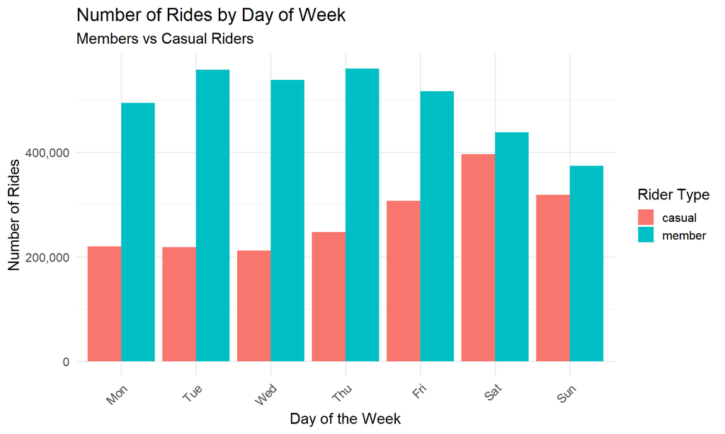

```r
all_trips_V2 %>%
  mutate(day_of_week = factor(day_of_week,
                              levels = c("Mon", "Tue", "Wed", "Thu", "Fri", "Sat", "Sun"))) %>%
  count(member_casual, day_of_week) %>%
  ggplot(mapping = aes(x = day_of_week, y = n, fill = member_casual)) +
  geom_col(position = "dodge") +
  labs(title = "Number of Rides by Day of Week",
       subtitle = "Members vs Casual Riders",
       x = "Day of the Week",
       y = "Number of Rides",
       fill = "Rider Type") +
  scale_y_continuous(labels = scales::comma) +
  theme_minimal(base_size = 15) +
  theme(axis.text.x = element_text(angle = 45, hjust = 1))
```

### Chart 2: Number of Rides by Month

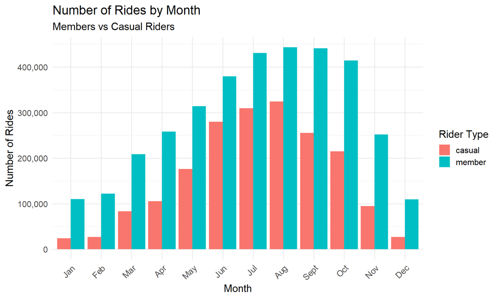

```r
all_trips_V2 %>%
  count(member_casual, month) %>%
  ggplot(mapping = aes(x = month, y = n, fill = member_casual)) +
  geom_col(position = "dodge") +
  labs(title = "Number of Rides by Month",
       subtitle = "Members vs Casual Riders",
       x = "Month",
       y = "Number of Rides",
       fill = "Rider Type") +
  scale_y_continuous(labels = scales::comma) +
  theme_minimal(base_size = 15) +
  theme(axis.text.x = element_text(angle = 45, hjust = 1))
```

**Key finding:** Both rider types peak in **summer (July–August)**, but casual riders drop **dramatically** in **winter (January: 23,964 rides)** while members remain far more consistent **year-round (January: 109,969 rides)**. This highlights the weather-dependent nature of casual riders.

### Chart 3: Average Ride Length by Day of Week

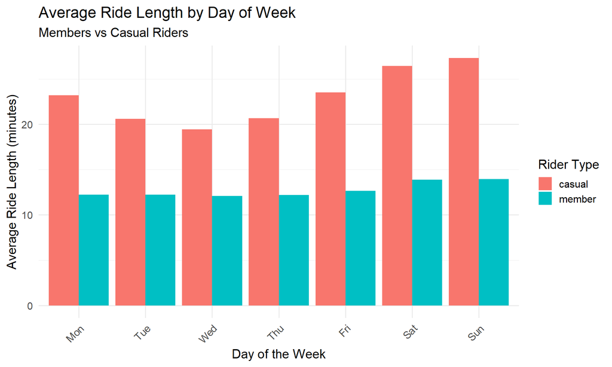

```r
all_trips_V2 %>%
  group_by(member_casual, day_of_week) %>%
  mutate(day_of_week = factor(day_of_week,
                              levels = c("Mon", "Tue", "Wed", "Thu", "Fri", "Sat", "Sun"))) %>%
  summarise(average_ride_length = mean(ride_length_mins)) %>%
  ggplot(aes(x = day_of_week, y = average_ride_length, fill = member_casual)) +
  geom_col(position = "dodge") +
  labs(title = "Average Ride Length by Day of Week",
       subtitle = "Members vs Casual Riders",
       x = "Day of the Week",
       y = "Average Ride Length (minutes)",
       fill = "Rider Type") +
  scale_y_continuous(labels = scales::comma) +
  theme_minimal(base_size = 15) +
  theme(axis.text.x = element_text(angle = 45, hjust = 1))
```

**Key finding:** Casual riders take their longest rides on **weekends (Sunday: 27.3 mins, Saturday: 26.4 mins)**, reinforcing the leisure-riding pattern. Members ride at a remarkably **consistent 12–14 minutes every day**, consistent with purposeful short commutes.

## 6. Act — Recommendations

Based on the analysis, the following three recommendations are made to help Cyclistic convert casual riders into annual members:

### Recommendation 1: Launch Weekend Conversion Campaigns Starting Thursday

Analysis shows casual riders peak on **Saturdays (396,411 rides)** and **Sundays (318,480 rides)**. Cyclistic should launch targeted digital and in-app marketing campaigns from **Thursday onwards** to capture casual riders during their highest-activity period. Ads should highlight the cost savings of annual membership for riders who already ride frequently on weekends, showing them that a membership quickly pays for itself.

### Recommendation 2: Promote Membership for Weekday Convenience and Short Trips

Casual riders average **23.5 minutes per ride** but their weekday ridership is significantly lower than members. Marketing should reframe membership not just as a leisure upgrade, but as a practical tool for **spontaneous weekday trips** — avoiding car use for short errands, unexpected commutes, or emergency situations. Messaging such as *“No car? No problem — your membership covers you any time”* could resonate with this segment.

### Recommendation 3: Run Seasonal Pre-Summer Membership Promotions

Casual ridership **surges in summer (June–August)** and drops sharply in winter. Cyclistic should launch **discounted membership offers in March and April**, just before the peak season begins, to convert casual riders into members before they reach their highest riding frequency. A limited-time spring offer could create urgency and capture riders already planning their cycling season.